# Web Crawling_IMDB

Mukta

10/31/2019

# Analysis of Top rated Sci-fi movies on IMDB website using R-Language.

## Introduction

The Internet Movie Database (IMDb) is a website that serves as an online database of world cinema. This website contains a large number of public data on films such as the title of the film, the year of release of the film, the genre of the film, the audience, the rating of critics, the duration of the film, the summary of the film, actors, directors and much more. Faced with the large amount of data available on this site, I thought that it would be interesting to analyze the movies data on the IMDb website on the top listed sci-fi movies.

# Calling libraries

```r
library(rvest)
library(esquisse)
```

```r
library(ggplot2)
library(corrplot)
library(dplyr)
library(plotly)
```

# Counter and placeholders

Created placeholders as empty vectors to use these later in the script to append the values.

```r
pg <-c(0,51,101,151,201,251,301,351,401,451,501,551,601,651,701)
title_list <- c()
rank_list <- c()
genre_list <- c()
runtime_list <- c()
imdb_rating_list <- c()
director_list <- c()
actor_list <- c()
poster_list <- c()
metascore_list <- c()
votes_list <- c()
gross_list <- c()
```

# Main code in loop to crawl all pages for Top scifi movie list

The code used to scrape the information from IMDB’s web page

```r
for(i in pg) {
  url <- read_html(paste0("https://www.imdb.com/search/title/?title_type=feature&num_votes=25000,&genres=sci-fi&sort=user_rating,desc&start=","i&ref_=adv_nxt"))

  #title
  title <- url %>%
    html_nodes(".mode-advanced") %>%
    html_node(".lister-item-header a") %>%
    html_text()
  # Append them to the list
  title_list <- append(title_list, title)

  #rank
  rank <- url %>%
    html_nodes(".mode-advanced") %>%
    html_node(".text-primary") %>%
    html_text()
  # Append them to the list
  rank_list <- append(rank_list, rank)

  #genre
  genre <- url %>%
    html_nodes(".mode-advanced") %>%
    html_node(".genre") %>%
    html_text()
  # Append them to the list
  genre_list <- append(genre_list, genre)

  #runtime_list
  runtime <- url %>%
    html_nodes(".mode-advanced") %>%
    html_node(".runtime") %>%
    html_text()
  # Append them to the list
  runtime_list <- append(runtime_list, runtime)

  #imdb rating
  imdb_rating <- url %>%
    html_nodes(".mode-advanced") %>%
    html_node(".ratings-imdb-rating strong") %>%
    html_text()
  # Append them to the list
  imdb_rating_list <- append(imdb_rating_list, imdb_rating)

  #director
  director <- url %>%
    html_nodes(".mode-advanced") %>%
    html_node(".text-muted+ p a:nth-child(1)") %>%
    html_text()
  # Append them to the list
  director_list <- append(director_list, director)

  #actor
  actor <- url %>%
    html_nodes(".mode-advanced") %>%
    html_node(".lister-item-content .ghost~ a") %>%
    html_text()
  # Append them to the list
  actor_list <- append(actor_list, actor)

  #poster
  poster <- url %>%
    html_nodes(".mode-advanced") %>%
    html_node(".loadlate") %>%
    html_attrs()
  # Append them to the list
  poster_list <- append(poster_list, poster)

  #metascore
  metascore <- url %>%
    html_nodes(".mode-advanced") %>%
    html_node(".metascore") %>%
    html_text()
  # Append them to the list
  metascore_list <- append(metascore_list, metascore)

  #votes
  votes <- url %>%
    html_nodes(".mode-advanced") %>%
    html_node(".sort-num_votes-visible span:nth-child(2)") %>%
    html_text()
  # Append them to the list
  votes_list <- append(votes_list, votes)

  #gross
  gross <- url %>%
    html_nodes(".mode-advanced") %>%
    html_node(".ghost~ .text-muted+ span") %>%
    html_text()
  # Append them to the list
  gross_list <- append(gross_list, gross)
}
```

# Removing unwanted texts or symbols

```r
runtime_list <- gsub(" min","",runtime_list)
genre_list <- gsub("\n","",genre_list)
genre_list <- gsub(",.*","",genre_list)
gross_list <- gsub("M","",gross_list)
gross_list <-substring(gross_list,2,6)
votes_list <- gsub(",","",votes_list)
```

# Converting into numbers and factors

```r
rank_list <- as.numeric(rank_list)
imdb_rating_list <- as.numeric(imdb_rating_list)
metascore_list <- as.numeric(metascore_list)
runtime_list <- as.numeric(runtime_list)
votes_list <- as.numeric(votes_list)
gross_list <- as.numeric(gross_list)

#convert as factor
# director_list <- as.factor(director_list)
# actor_list <- as.factor(actor_list)
```

# Create a dataframe combining all above lists

```r
imdb_toplist_scifi_df <- data.frame(Rank=rank_list, Title = title_list,
                                    Imdb_rating=imdb_rating_list,Metascore=metascore_list,
                                Runtime=runtime_list, Genre=genre_list,
                                Gross=gross_list, Votes=votes_list,
                                Director=director_list, Starcast=actor_list)

head(imdb_toplist_scifi_df)
```

```
##   Rank                                          Title Imdb_rating
## 1    1                                      Inception         8.8
## 2    2                                     The Matrix         8.7
## 3    3 Star Wars: Episode V - The Empire Strikes Back         8.7
## 4    4                                   Interstellar         8.6
## 5    5             Star Wars: Episode IV - A New Hope         8.6
## 6    6                              Avengers: Endgame         8.5
##   Metascore Runtime     Genre Gross   Votes          Director
## 1        74     148    Action 292.5 1887724 Christopher Nolan
## 2        73     136    Action 171.4 1549862    Lana Wachowski
## 3        82     124    Action 290.4 1075892    Irvin Kershner
## 4        74     169 Adventure 188.0 1343228 Christopher Nolan
## 5        90     121    Action 322.7 1144462      George Lucas
## 6        78     181    Action 858.3  591797     Anthony Russo
##              Starcast
## 1   Leonardo DiCaprio
## 2        Keanu Reeves
## 3         Mark Hamill
## 4 Matthew McConaughey
## 5         Mark Hamill
## 6   Robert Downey Jr.
```

# Corelation between rank, imdb rating , gross and votes

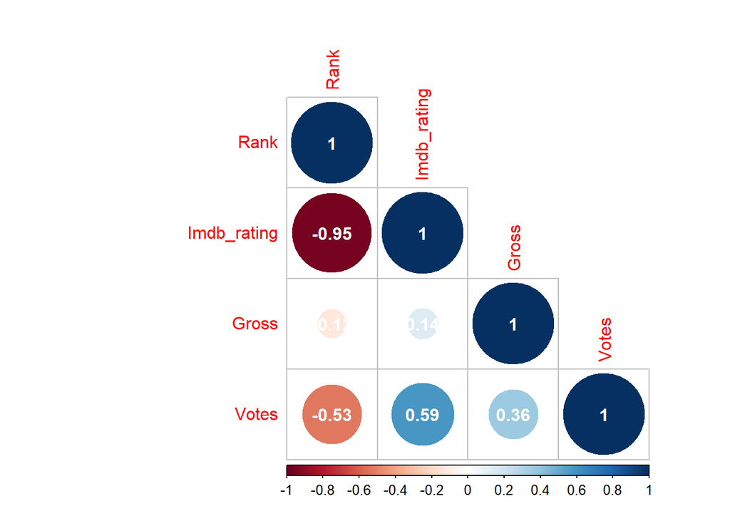

```r
mydata <- imdb_toplist_scifi_df[, c(1,3,7,8)]

#remove NAs
data <- na.omit(mydata)
corr <- cor(data)

corrplot(corr,type="lower",addCoef.col = "white")
```